# Lab 4 : Data wrangling and graphing COVID-19 reporting data (Part 1)

#### 2. Many countries have multiple entries representing different regions (e.g. counties and states). To get the counts for a country we need to summarise the data. Use group_by() and summarize() to make a data frame (tibble) with total counts for each country.

```r
report_03_13_2020_Total <- report_03_13_2020 %>%
  group_by(Country_Region) %>%
  summarize(Confirmed_total_counts = sum(Confirmed),
            Deaths_total_counts = sum(Deaths),
            Recovered_total_counts = sum(Recovered))
report_09_13_2020_Total <- report_09_13_2020 %>%
  group_by(Country_Region) %>%
  summarize(Confirmed_total_counts = sum(Confirmed),
            Deaths_total_counts = sum(Deaths),
            Recovered_total_counts = sum(Recovered))
datatable(report_03_13_2020_Total)
```

|  | Country_Region | Confirmed_total_counts | Deaths_total_counts | Recovered_total_counts |
| --- | --- | --- | --- | --- |
| 1 | Afghanistan | 7 | 0 | 0 |
| 2 | Albania | 12 | 1 | 0 |
| 3 | Algeria | 20 | 0 | 0 |
| 4 | Andorra | 1 | 0 | 0 |
| 5 | Argentina | 19 | 1 | 0 |
| 6 | Armenia | 1 | 0 | 0 |
| 7 | Australia | 128 | 3 | 21 |
| 8 | Austria | 246 | 0 | 4 |
| 9 | Azerbaijan | 11 | 0 | 3 |
| 10 | Bahrain | 195 | 0 | 35 |

[output cut: 106 more lines]

```r
datatable(report_09_13_2020_Total)
```

|  | Country_Region | Confirmed_total_counts | Deaths_total_counts | Recovered_total_counts |
| --- | --- | --- | --- | --- |
| 1 | Afghanistan | 38716 | 1420 | 31638 |
| 2 | Albania | 11353 | 334 | 6569 |
| 3 | Algeria | 48254 | 1612 | 34037 |
| 4 | Andorra | 1344 | 53 | 943 |
| 5 | Angola | 3388 | 134 | 1301 |
| 6 | Antigua and Barbuda | 95 | 3 | 91 |
| 7 | Argentina | 555537 | 11352 | 419513 |
| 8 | Armenia | 45862 | 916 | 41659 |
| 9 | Australia | 26692 | 816 | 23463 |
| 10 | Austria | 33159 | 756 | 26760 |

[output cut: 178 more lines]

#### 3. To get counts for confirmed cases per U.S state use filter() to select US and group_by and summarize as above.

```r
report_03_13_2020_US <- report_03_13_2020 %>%
  filter(Country_Region == "US") %>%
  group_by(Province_State) %>%
  summarize(Confirmed_total_counts = sum(Confirmed),
            Deaths_total_counts = sum(Deaths),
            Recovered_total_counts = sum(Recovered))
report_09_13_2020_US <- report_09_13_2020 %>%
  filter(Country_Region == "US") %>%
  filter(Province_State != "Recovered") %>%
  group_by(Province_State) %>%
  summarize(Confirmed_total_counts = sum(Confirmed),
            Deaths_total_counts = sum(Deaths),
            Recovered_total_counts = sum(Recovered))
datatable(report_03_13_2020_US)
```

|  | Province_State | Confirmed_total_counts | Deaths_total_counts | Recovered_total_counts |
| --- | --- | --- | --- | --- |
| 1 | Alaska | 0 | 0 | 0 |
| 2 | Arizona | 9 | 0 | 1 |
| 3 | Arkansas | 1 | 0 | 0 |
| 4 | California | 177 | 3 | 2 |
| 5 | Colorado | 34 | 0 | 0 |
| 6 | Connecticut | 3 | 0 | 0 |
| 7 | Delaware | 1 | 0 | 0 |
| 8 | Diamond Princess | 46 | 0 | 0 |
| 9 | District of Columbia | 10 | 0 | 0 |
| 10 | Florida | 28 | 2 | 0 |

[output cut: 42 more lines]

```r
datatable(report_09_13_2020_US)
```

|  | Province_State | Confirmed_total_counts | Deaths_total_counts | Recovered_total_counts |
| --- | --- | --- | --- | --- |
| 1 | Alabama | 138755 | 2351 | 0 |
| 2 | Alaska | 6268 | 44 | 0 |
| 3 | Arizona | 208512 | 5322 | 0 |
| 4 | Arkansas | 70219 | 981 | 0 |
| 5 | California | 761728 | 14378 | 0 |
| 6 | Colorado | 61293 | 1988 | 0 |
| 7 | Connecticut | 54326 | 4480 | 0 |
| 8 | Delaware | 18849 | 615 | 0 |
| 9 | Diamond Princess | 49 | 0 | 0 |
| 10 | District of Columbia | 14592 | 616 | 0 |

[output cut: 47 more lines]

#### 4. It will be difficult to make simple graphs with the data from all countries in the world or even the US states. Use arrange_by() and slice() to get just the top 10 countries for Deaths.

```r
report_03_13_2020_top10_Deaths <- report_03_13_2020 %>%
  group_by(Country_Region) %>%
  summarize(Confirmed_total_counts = sum(Confirmed),
            Deaths_total_counts = sum(Deaths),
            Recovered_total_counts = sum(Recovered)) %>%
  arrange(desc(Deaths_total_counts)) %>%
  slice(1:10)
report_09_13_2020_top10_Deaths <- report_09_13_2020 %>%
  group_by(Country_Region) %>%
  summarize(Confirmed_total_counts = sum(Confirmed),
            Deaths_total_counts = sum(Deaths),
            Recovered_total_counts = sum(Recovered)) %>%
  arrange(desc(Deaths_total_counts)) %>%
  slice(1:10)
datatable(report_03_13_2020_top10_Deaths)
```

|  | Country_Region | Confirmed_total_counts | Deaths_total_counts | Recovered_total_counts |
| --- | --- | --- | --- | --- |
| 1 | China | 80921 | 3161 | 61644 |
| 2 | Italy | 12462 | 827 | 1045 |
| 3 | Iran | 9000 | 354 | 2959 |
| 4 | Korea, South | 7755 | 60 | 288 |
| 5 | Spain | 2277 | 54 | 183 |
| 6 | France | 2284 | 48 | 12 |
| 7 | US | 1281 | 36 | 8 |
| 8 | Japan | 639 | 15 | 118 |
| 9 | United Kingdom | 459 | 8 | 19 |
| 10 | Cruise Ship | 696 | 7 | 325 |

```r
datatable(report_09_13_2020_top10_Deaths)
```

|  | Country_Region | Confirmed_total_counts | Deaths_total_counts | Recovered_total_counts |
| --- | --- | --- | --- | --- |
| 1 | US | 6519573 | 194071 | 2451406 |
| 2 | Brazil | 4330455 | 131625 | 3723206 |
| 3 | India | 4754356 | 78586 | 3702595 |
| 4 | Mexico | 668381 | 70821 | 557381 |
| 5 | United Kingdom | 370930 | 41717 | 2146 |
| 6 | Italy | 287753 | 35610 | 213634 |
| 7 | France | 402893 | 30903 | 90445 |
| 8 | Peru | 722832 | 30526 | 559321 |
| 9 | Spain | 566326 | 29747 | 150376 |
| 10 | Iran | 402029 | 23157 | 346242 |

# Introduction to R Graphics

https://datacarpentry.org/R-ecology-lesson/04-visualization-ggplot2.html

Load the package

```r
#install.packages("tidyverse")
library(tidyverse)
```

## Exercises (Part 2)

How to reorder ggplot https://sebastiansauer.github.io/ordering-bars/

```r
# Subset for top 10 confirmed cases
report_03_13_2020_top10_Confirmed <- report_03_13_2020 %>%
  group_by(Country_Region) %>%
  summarize(Confirmed_total_counts = sum(Confirmed),
            Deaths_total_counts = sum(Deaths),
            Recovered_total_counts = sum(Recovered)) %>%
  arrange(desc(Confirmed_total_counts)) %>%
  slice(1:10)
report_09_13_2020_top10_Confirmed <- report_09_13_2020 %>%
  group_by(Country_Region) %>%
  summarize(Confirmed_total_counts = sum(Confirmed),
            Deaths_total_counts = sum(Deaths),
            Recovered_total_counts = sum(Recovered)) %>%
  arrange(desc(Confirmed_total_counts)) %>%
  slice(1:10)
datatable(report_03_13_2020_top10_Confirmed)
```

|  | Country_Region | Confirmed_total_counts | Deaths_total_counts | Recovered_total_counts |
| --- | --- | --- | --- | --- |
| 1 | China | 80921 | 3161 | 61644 |
| 2 | Italy | 12462 | 827 | 1045 |
| 3 | Iran | 9000 | 354 | 2959 |
| 4 | Korea, South | 7755 | 60 | 288 |
| 5 | France | 2284 | 48 | 12 |
| 6 | Spain | 2277 | 54 | 183 |
| 7 | Germany | 1908 | 3 | 25 |
| 8 | US | 1281 | 36 | 8 |
| 9 | Cruise Ship | 696 | 7 | 325 |
| 10 | Switzerland | 652 | 4 | 4 |

```r
datatable(report_09_13_2020_top10_Confirmed)
```

|  | Country_Region | Confirmed_total_counts | Deaths_total_counts | Recovered_total_counts |
| --- | --- | --- | --- | --- |
| 1 | US | 6519573 | 194071 | 2451406 |
| 2 | India | 4754356 | 78586 | 3702595 |
| 3 | Brazil | 4330455 | 131625 | 3723206 |
| 4 | Russia | 1059024 | 18517 | 873684 |
| 5 | Peru | 722832 | 30526 | 559321 |
| 6 | Colombia | 716319 | 22924 | 599385 |
| 7 | Mexico | 668381 | 70821 | 557381 |
| 8 | South Africa | 649793 | 15447 | 577906 |
| 9 | Spain | 566326 | 29747 | 150376 |
| 10 | Argentina | 555537 | 11352 | 419513 |

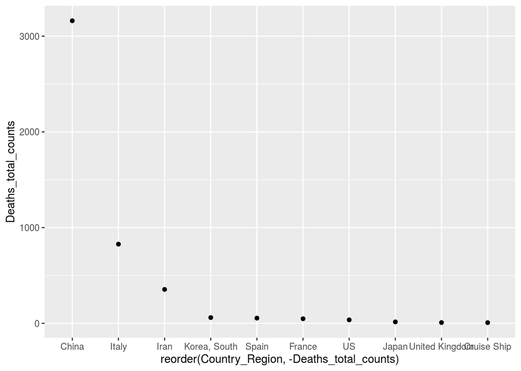

```r
# Total Death top 10
ggplot(data = report_03_13_2020_top10_Deaths, aes(x = reorder(Country_Region,-Deaths_total_counts), y = Deaths_total_counts)) +
  geom_point()
```

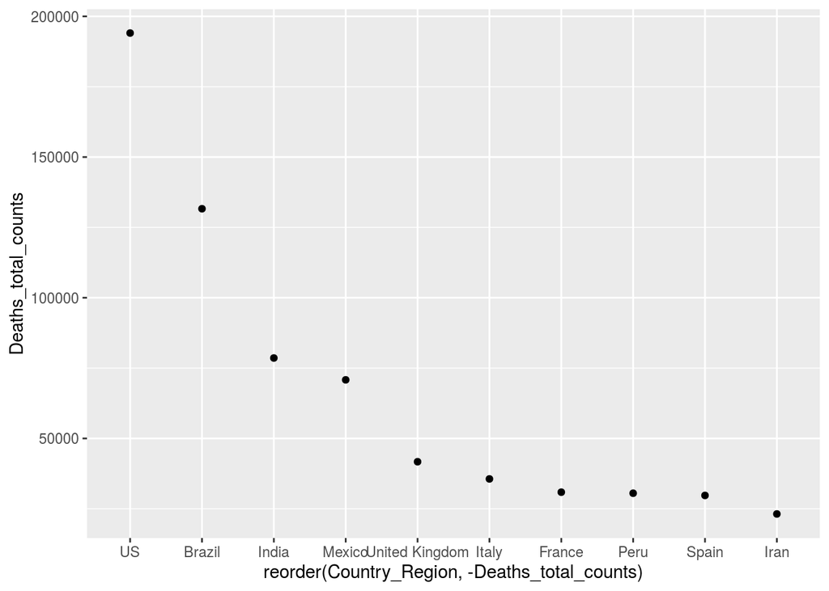

```r
ggplot(data = report_09_13_2020_top10_Deaths, aes(x = reorder(Country_Region,-Deaths_total_counts), y = Deaths_total_counts)) +
  geom_point()
```

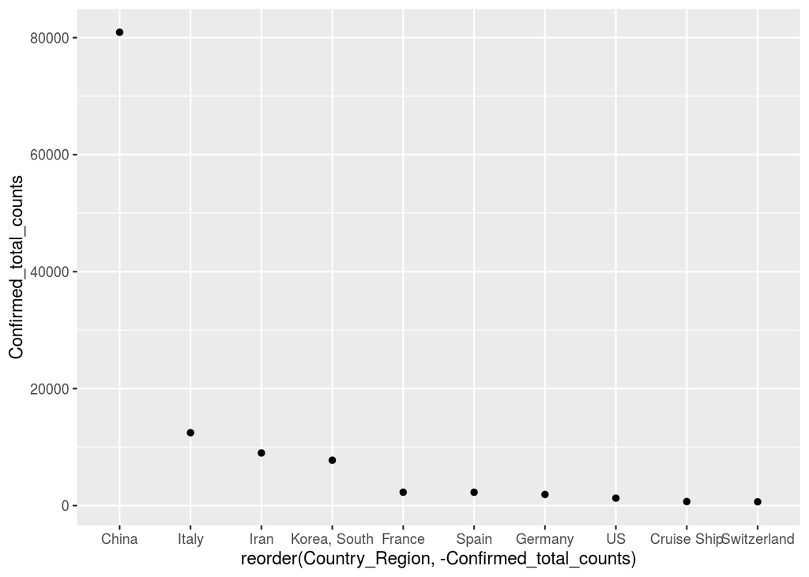

```r
# Total confirmed cases top 10
ggplot(data = report_03_13_2020_top10_Confirmed, aes(x = reorder(Country_Region,-Confirmed_total_counts), y = Confirmed_total_counts)) +
  geom_point()
```

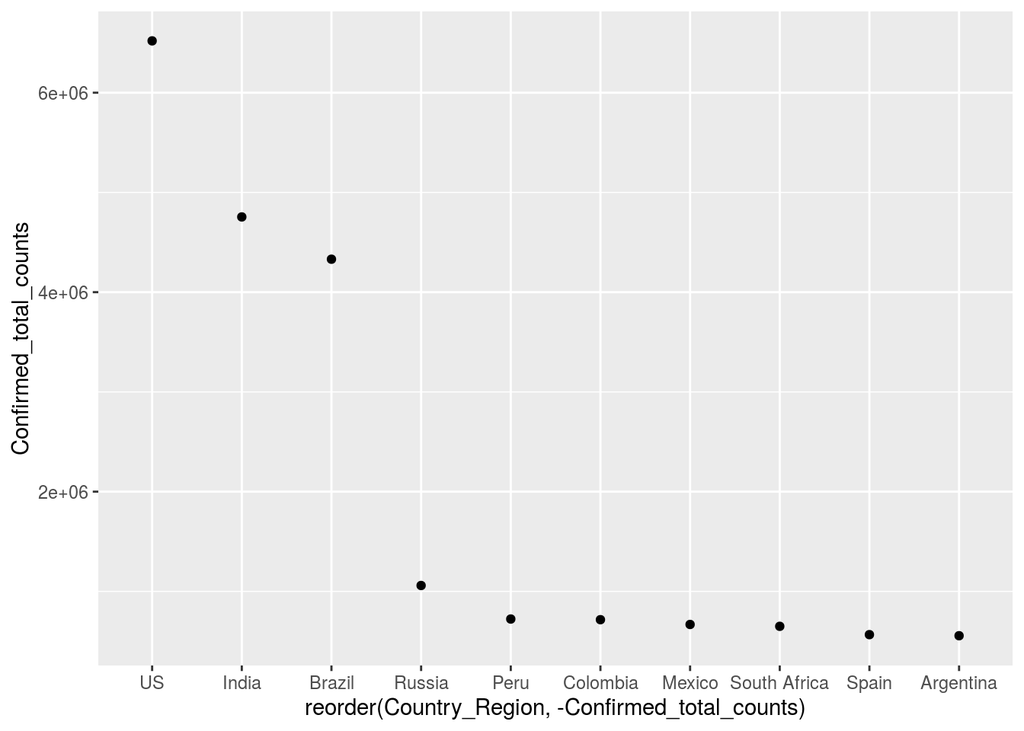

```r
ggplot(data = report_09_13_2020_top10_Confirmed, aes(x = reorder(Country_Region,-Confirmed_total_counts), y = Confirmed_total_counts)) +
  geom_point()
```

http://www.sthda.com/english/wiki/ggplot2-barplots-quick-start-guide-r-software-and-data-visualization

```r
# create subset
report_03_13_2020_top10_States_Confirmed <- report_03_13_2020 %>%
  filter(Country_Region == "US") %>%
  group_by(Province_State) %>%
  summarize(Confirmed_total_counts = sum(Confirmed),
            Deaths_total_counts = sum(Deaths),
            Recovered_total_counts = sum(Recovered)) %>%
  arrange(desc(Confirmed_total_counts)) %>%
  slice(1:10)
report_09_13_2020_top10_States_Confirmed <- report_09_13_2020 %>%
  filter(Country_Region == "US") %>%
  group_by(Province_State) %>%
  summarize(Confirmed_total_counts = sum(Confirmed),
            Deaths_total_counts = sum(Deaths),
            Recovered_total_counts = sum(Recovered)) %>%
  arrange(desc(Confirmed_total_counts)) %>%
  slice(1:10)
report_03_13_2020_top10_States_Deaths <- report_03_13_2020 %>%
  filter(Country_Region == "US") %>%
  group_by(Province_State) %>%
  summarize(Confirmed_total_counts = sum(Confirmed),
            Deaths_total_counts = sum(Deaths),
            Recovered_total_counts = sum(Recovered)) %>%
  arrange(desc(Deaths_total_counts)) %>%
  slice(1:10)
report_09_13_2020_top10_States_Deaths <- report_09_13_2020 %>%
  filter(Country_Region == "US") %>%
  group_by(Province_State) %>%
  summarize(Confirmed_total_counts = sum(Confirmed),
            Deaths_total_counts = sum(Deaths),
            Recovered_total_counts = sum(Recovered)) %>%
  arrange(desc(Deaths_total_counts)) %>%
  slice(1:10)
datatable(report_03_13_2020_top10_States_Confirmed)
```

|  | Province_State | Confirmed_total_counts | Deaths_total_counts | Recovered_total_counts |
| --- | --- | --- | --- | --- |
| 1 | Washington | 366 | 29 | 1 |
| 2 | New York | 220 | 0 | 0 |
| 3 | California | 177 | 3 | 2 |
| 4 | Massachusetts | 95 | 0 | 1 |
| 5 | Diamond Princess | 46 | 0 | 0 |
| 6 | Colorado | 34 | 0 | 0 |
| 7 | Florida | 28 | 2 | 0 |
| 8 | Illinois | 25 | 0 | 2 |
| 9 | Georgia | 23 | 0 | 0 |
| 10 | New Jersey | 23 | 1 | 0 |

```r
datatable(report_09_13_2020_top10_States_Confirmed)
```

|  | Province_State | Confirmed_total_counts | Deaths_total_counts | Recovered_total_counts |
| --- | --- | --- | --- | --- |
| 1 | California | 761728 | 14378 | 0 |
| 2 | Texas | 681885 | 14405 | 0 |
| 3 | Florida | 663994 | 12608 | 0 |
| 4 | New York | 444365 | 33023 | 0 |
| 5 | Georgia | 294314 | 6333 | 0 |
| 6 | Illinois | 263459 | 8541 | 0 |
| 7 | Arizona | 208512 | 5322 | 0 |
| 8 | New Jersey | 196634 | 16031 | 0 |
| 9 | North Carolina | 184936 | 3052 | 0 |
| 10 | Tennessee | 171824 | 2078 | 0 |

```r
datatable(report_03_13_2020_top10_States_Deaths)
```

|  | Province_State | Confirmed_total_counts | Deaths_total_counts | Recovered_total_counts |
| --- | --- | --- | --- | --- |
| 1 | Washington | 366 | 29 | 1 |
| 2 | California | 177 | 3 | 2 |
| 3 | Florida | 28 | 2 | 0 |
| 4 | New Jersey | 23 | 1 | 0 |
| 5 | South Dakota | 8 | 1 | 0 |
| 6 | Alaska | 0 | 0 | 0 |
| 7 | Arizona | 9 | 0 | 1 |
| 8 | Arkansas | 1 | 0 | 0 |
| 9 | Colorado | 34 | 0 | 0 |
| 10 | Connecticut | 3 | 0 | 0 |

```r
datatable(report_09_13_2020_top10_States_Deaths)
```

|  | Province_State | Confirmed_total_counts | Deaths_total_counts | Recovered_total_counts |
| --- | --- | --- | --- | --- |
| 1 | New York | 444365 | 33023 | 0 |
| 2 | New Jersey | 196634 | 16031 | 0 |
| 3 | Texas | 681885 | 14405 | 0 |
| 4 | California | 761728 | 14378 | 0 |
| 5 | Florida | 663994 | 12608 | 0 |
| 6 | Massachusetts | 124826 | 9210 | 0 |
| 7 | Illinois | 263459 | 8541 | 0 |
| 8 | Pennsylvania | 148635 | 7829 | 0 |
| 9 | Michigan | 123058 | 6911 | 0 |
| 10 | Georgia | 294314 | 6333 | 0 |

Label Wrapping: https://stackoverflow.com/questions/21878974/auto-wrapping-of-labels-via-labeller-label-wrap-in-ggplot2

```r
library(stringr)
```

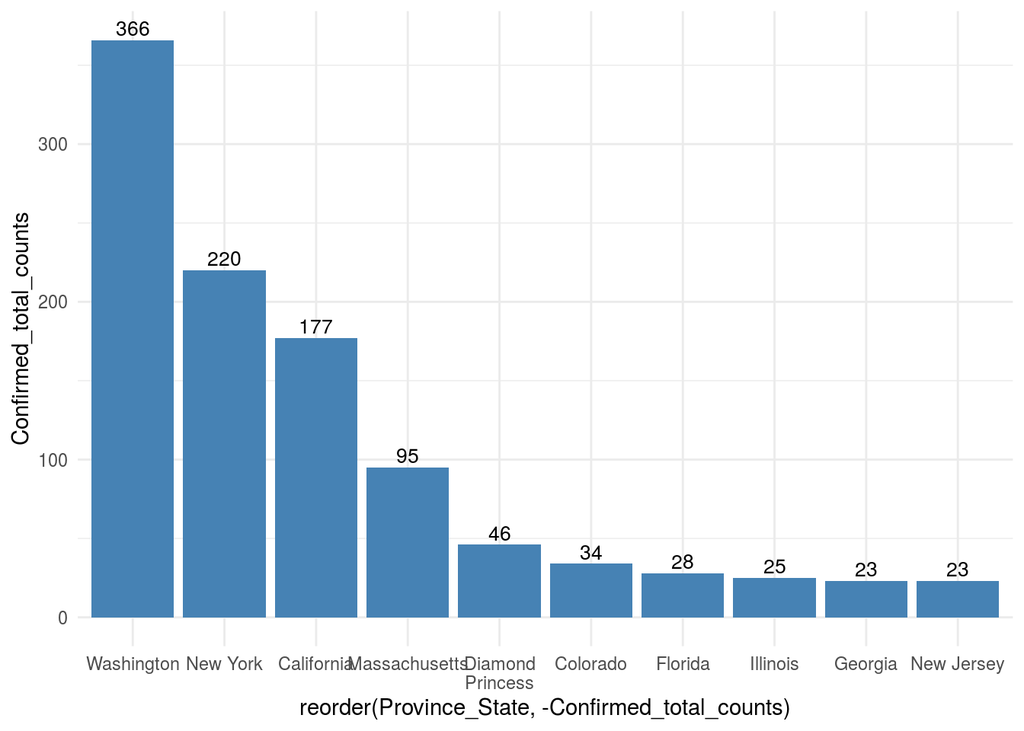

```r
# Total Confirmed top 10 States
ggplot(data = report_03_13_2020_top10_States_Confirmed, aes(x = reorder(Province_State,-Confirmed_total_counts), y = Confirmed_total_counts)) +
  geom_bar(stat="identity", fill="steelblue")+
  geom_text(aes(label = Confirmed_total_counts), vjust=-0.3, size=3.5)+
  theme_minimal()+
  scale_x_discrete(labels = function(x) str_wrap(x, width = 10))
```

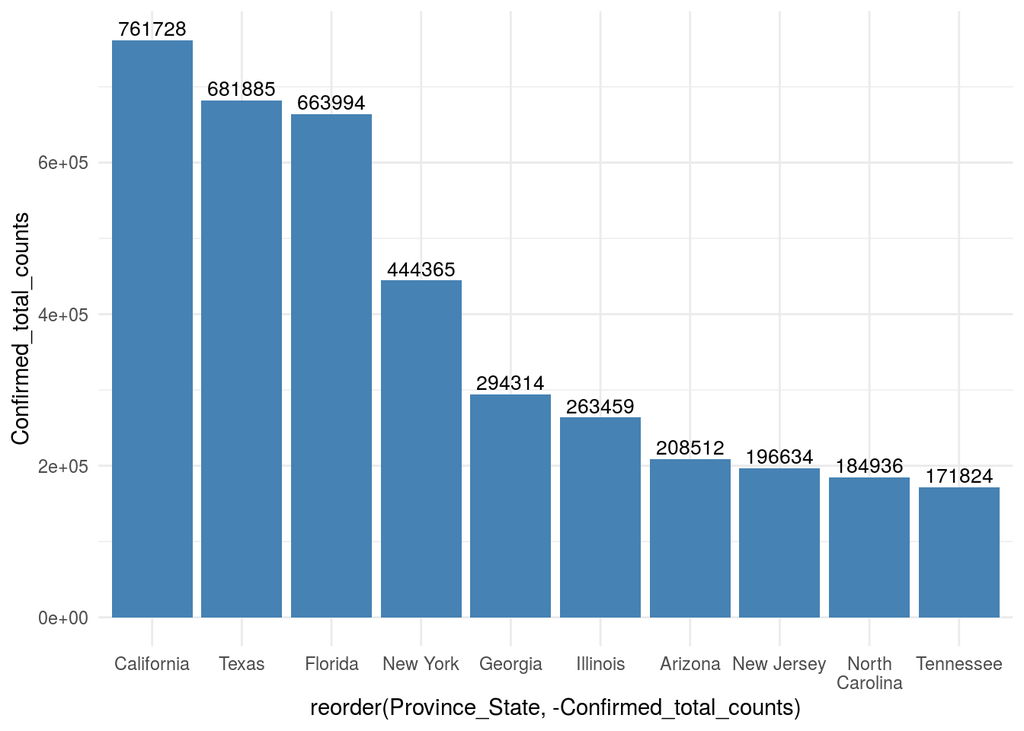

```r
ggplot(data = report_09_13_2020_top10_States_Confirmed, aes(x = reorder(Province_State,-Confirmed_total_counts), y = Confirmed_total_counts)) +
  geom_bar(stat="identity", fill="steelblue")+
  geom_text(aes(label = Confirmed_total_counts), vjust=-0.3, size=3.5)+
  theme_minimal()+
  scale_x_discrete(labels = function(x) str_wrap(x, width = 10))
```

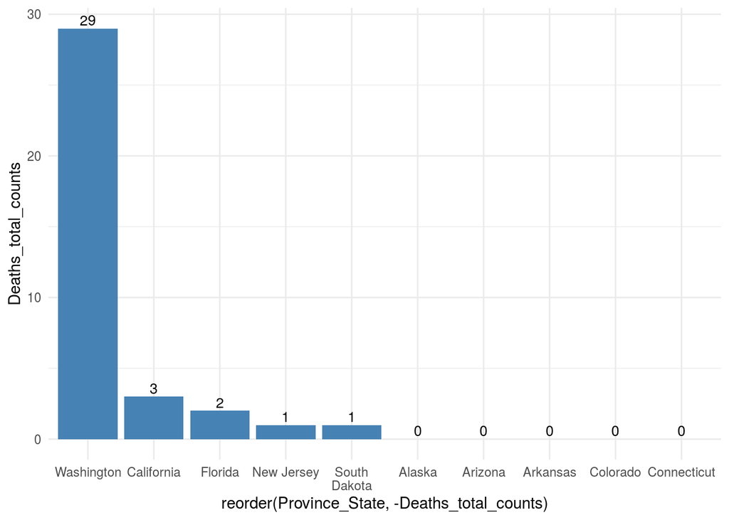

```r
# Total Death top 10 States

ggplot(data = report_03_13_2020_top10_States_Deaths, aes(x = reorder(Province_State,-Deaths_total_counts), y = Deaths_total_counts)) +
  geom_bar(stat="identity", fill="steelblue")+
  geom_text(aes(label = Deaths_total_counts), vjust=-0.3, size=3.5)+
  theme_minimal()+
  scale_x_discrete(labels = function(x) str_wrap(x, width = 10))
```

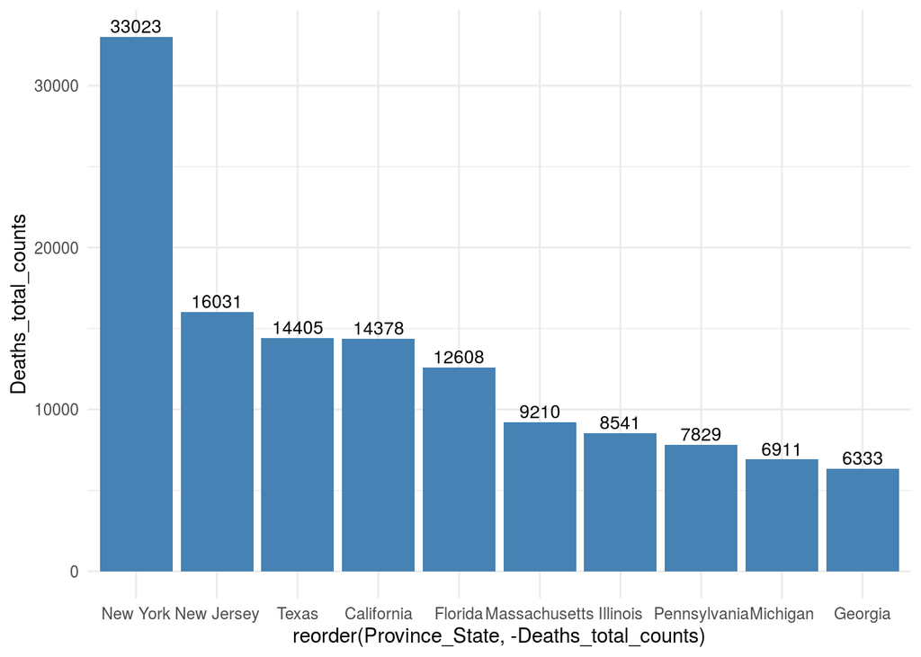

```r
ggplot(data = report_09_13_2020_top10_States_Deaths, aes(x = reorder(Province_State,-Deaths_total_counts), y = Deaths_total_counts)) +
  geom_bar(stat="identity", fill="steelblue")+
  geom_text(aes(label = Deaths_total_counts), vjust=-0.3, size=3.5)+
  theme_minimal()+
  scale_x_discrete(labels = function(x) str_wrap(x, width = 10))
```